# Univariate Relationships with Absolute Deviation

MPT Reanalysis Project (code and text current document: Henrik Singmann)

Results from: 2020-05-14

# Overview

This document provides an overview of the univariate relationships of all covariates with the absolute parameter deviation. We separate the relationships by focussing on one method as the target method and then investigating the relationships for each of the remaining methods with this method.

# DV: Absolute Deviation from Complete Pooling MLE Estimate

We begin by investigating the abolsute relationship from the simplest method, the complete pooling MLE method. This leaves us with 13921 observations for the analysis.

## Effect of Method

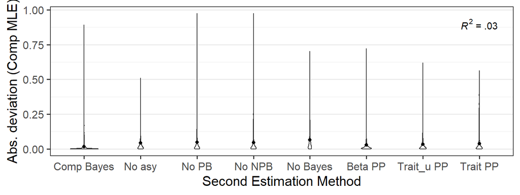

## Effects of Continuous Covariates

In the following plots, the blue line shows the fitted model (in case it is not a simple linear relationship, the transformation of the independent variable is given in parentheses in the x-axis label). The $R^2$ value shon in the plot is the $R^2$ of this model (i.e., the blue line). The red line shows a GAM on the independent variable with shrinkage applied cubic regression spline.

In case observations had to be removed for the analysis, the percentage of removed (rem) observations is also shown in the x-axis caption.

### Effect of Parameter Estimate

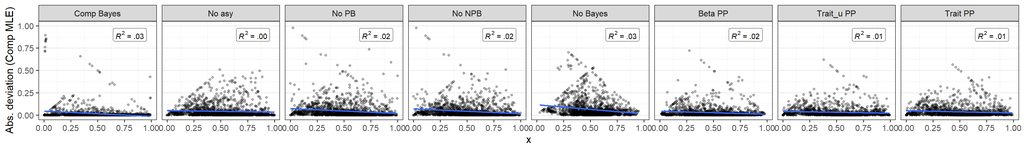

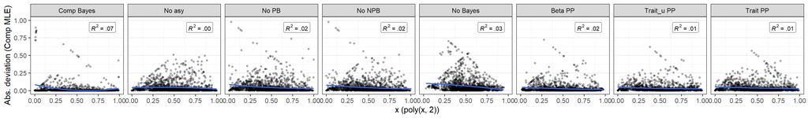

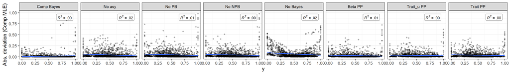

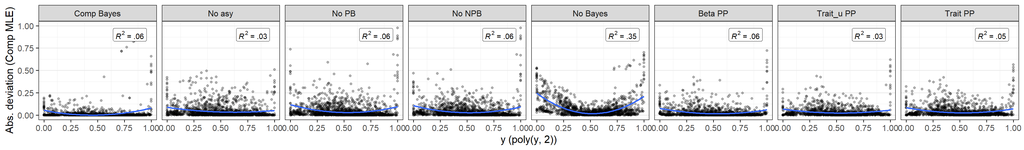

### Standard Error

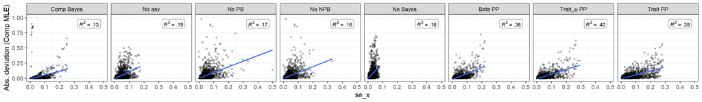

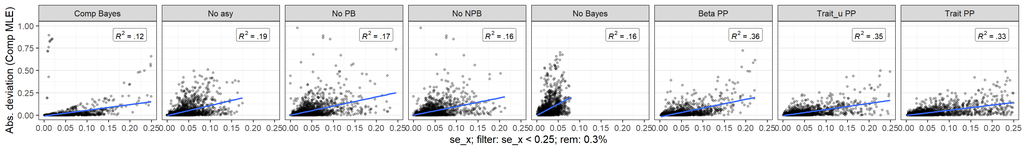

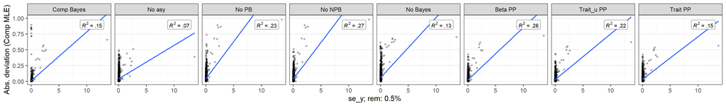

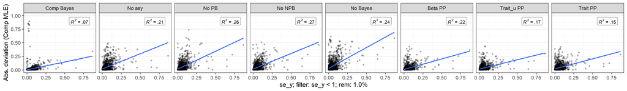

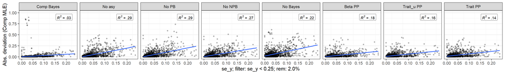

### Hetereogeneity

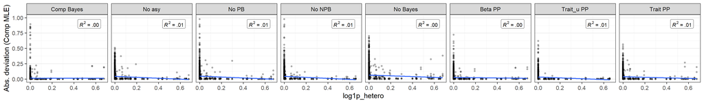

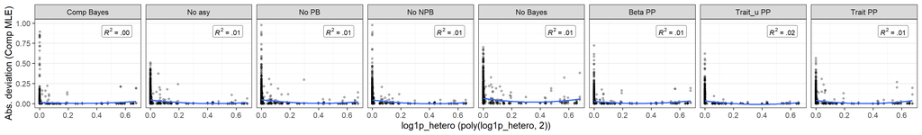

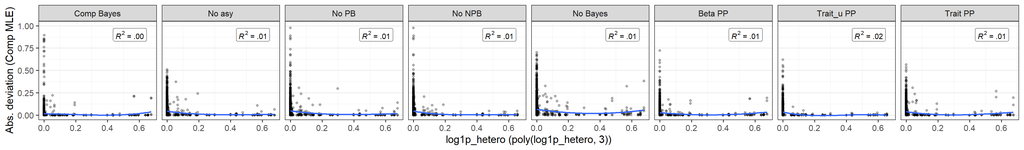

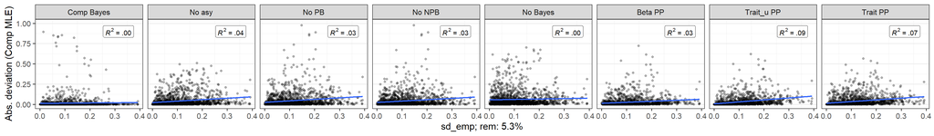

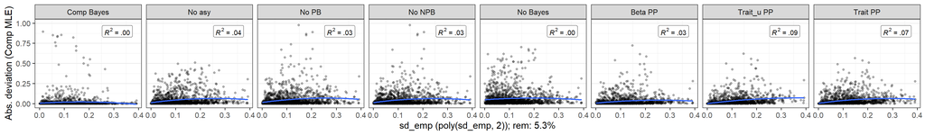

### Rho

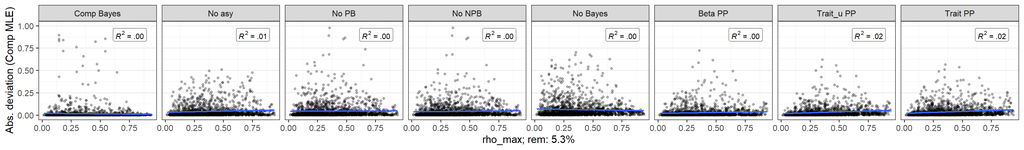

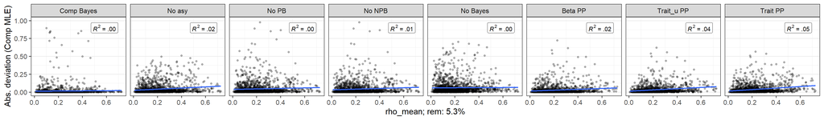

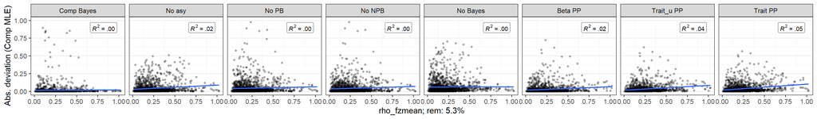

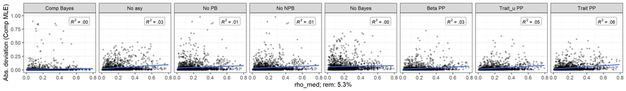

### Fungibility

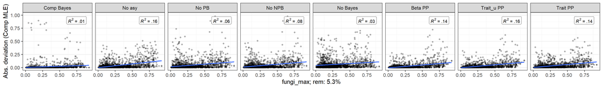

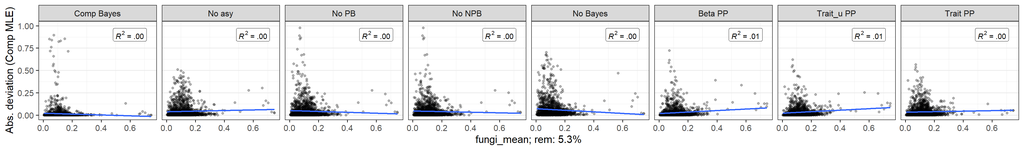

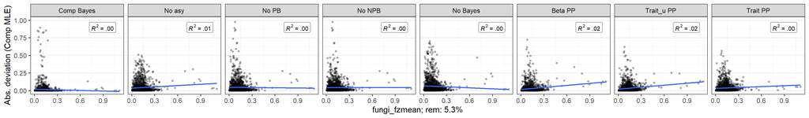

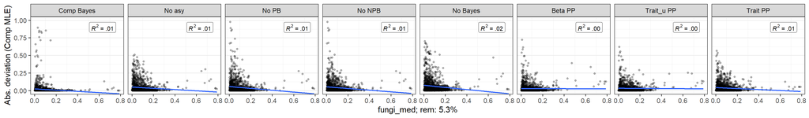

### Model Fit

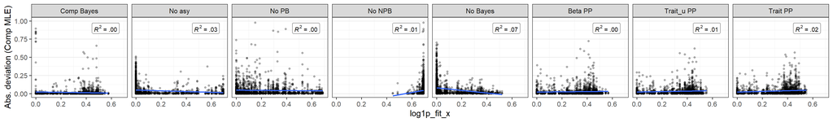

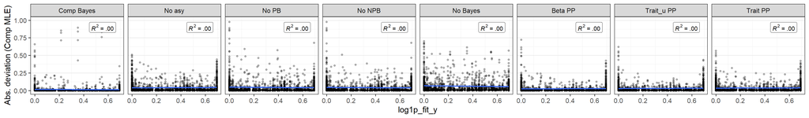

### Relative Parameter Information

[figure not shown]

[figure not shown]

## Effects of Categroical Covariates

The effect of covariate is shown in two ways. The table below all plots gives the $R^2$ values for the model given the covariate across all comparison methods. In case the number of levels is not too large, a plot of the difference in absolute deviation conditional on the factor levels is shown. Some factor levels may be removed for plotting (i.e., those levels for which the proportion of observations is less than 0.04). In this case, the number of removed levels is also given.

### Meta Data

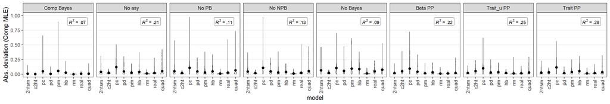

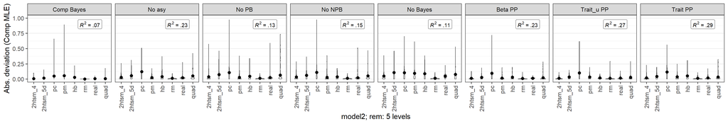

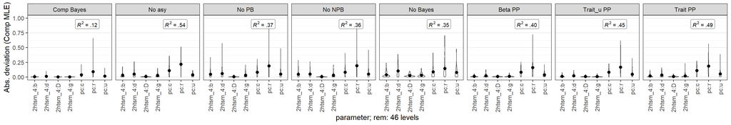

```
## # A tibble: 4 x 10
##   covariate nlevels `Beta PP` `Comp Bayes` `No asy` `No Bayes` `No NPB` `No PB` `Trait PP` `Trait_u PP`
##   <chr>       <int>     <dbl>        <dbl>    <dbl>      <dbl>    <dbl>   <dbl>      <dbl>        <dbl>
## 1 model           9     0.217       0.0706    0.210     0.0852    0.132   0.107      0.283        0.252
## 2 model2         13     0.230       0.0720    0.234     0.112     0.152   0.129      0.292        0.270
## 3 parameter      53     0.402       0.120     0.536     0.351     0.358   0.369      0.488        0.453
## 4 dataset       166     0.328       0.655     0.301     0.285     0.219   0.199      0.334        0.343
```

### Categorical Covariates

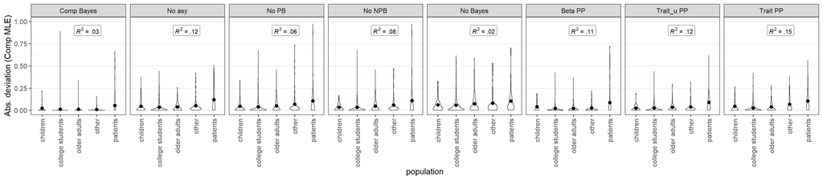

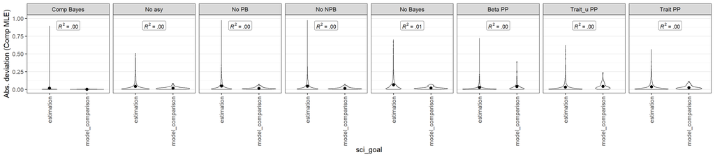

```
## # A tibble: 2 x 10
##   covariate  nlevels `Beta PP` `Comp Bayes` `No asy` `No Bayes` `No NPB` `No PB` `Trait PP` `Trait_u PP`
##   <chr>        <int>     <dbl>        <dbl>    <dbl>      <dbl>    <dbl>   <dbl>      <dbl>        <dbl>
## 1 population       5   0.115        0.0293   0.124      0.0227   0.0818  0.0572     0.153        0.122
## 2 sci_goal         2   0.00127      0.00151  0.00445    0.00643  0.00428 0.00443    0.00140      0.00120
```